# Breaking Bad Viewership & Rating Analysis

Kamil Laskowski 441202

2026-05-05

## Description

*Breaking Bad* is an American television drama series created by *Vince Gilligan* for the cable network AMC. The series follows *Walter White* (*Bryan Cranston*), a 50-year-old high school chemistry teacher in Albuquerque, New Mexico. After White is diagnosed with terminal lung cancer, he uses his chemistry expertise to cook crystal meth, assisted by his former student *Jesse Pinkman* (*Aaron Paul*), to secure his family’s (played by *Anna Gunn* and *RJ Mitte*) inheritance before he dies.

*source: Wikipedia*

## Image

[figure not shown]

## Summary statistics about viewers

```r
#AI assisted viewers data extraction from https://en.wikipedia.org/wiki/List_of_Breaking_Bad_episodes
viewers <- c(
  1.41, 1.49, 1.08, 1.09, 0.97, 1.07, 1.50, 1.66, 1.60, 1.13, 1.29, 1.21, 1.41, 1.20, 1.04, 1.27, 1.19, 1.29, 1.19, 1.50, 1.95, 1.55, 1.33, 1.46, 1.61, 1.64, 1.52, 1.78, 1.61, 1.20, 1.32, 1.19, 1.56, 2.58, 1.97, 1.71, 1.83, 1.75, 1.67, 1.91, 1.98, 1.89, 1.80, 1.55, 1.73, 1.90, 2.93, 2.29, 2.20, 2.29, 2.48, 2.81, 2.98, 2.78, 5.92, 4.77, 4.85, 4.41, 5.11, 6.37, 6.58, 10.28
)

mean(viewers)
```

```
## [1] 2.235968
```

```r
median(viewers)
```

```
## [1] 1.65
```

```r
min(viewers)
```

```
## [1] 0.97
```

```r
max(viewers)
```

```
## [1] 10.28
```

```r
sd(viewers)
```

```
## [1] 1.674573
```

The average viewership across all episodes is approximately 2.24 million viewers. The minimum average episode viewership was 0.97 million (Season 1, Episode 5), while the maximumreached 10.28 million (Season 5B, Episode 8). The data shows a clear upward trend, indicating that the show gained significant popularity over time.

## Viewership over time

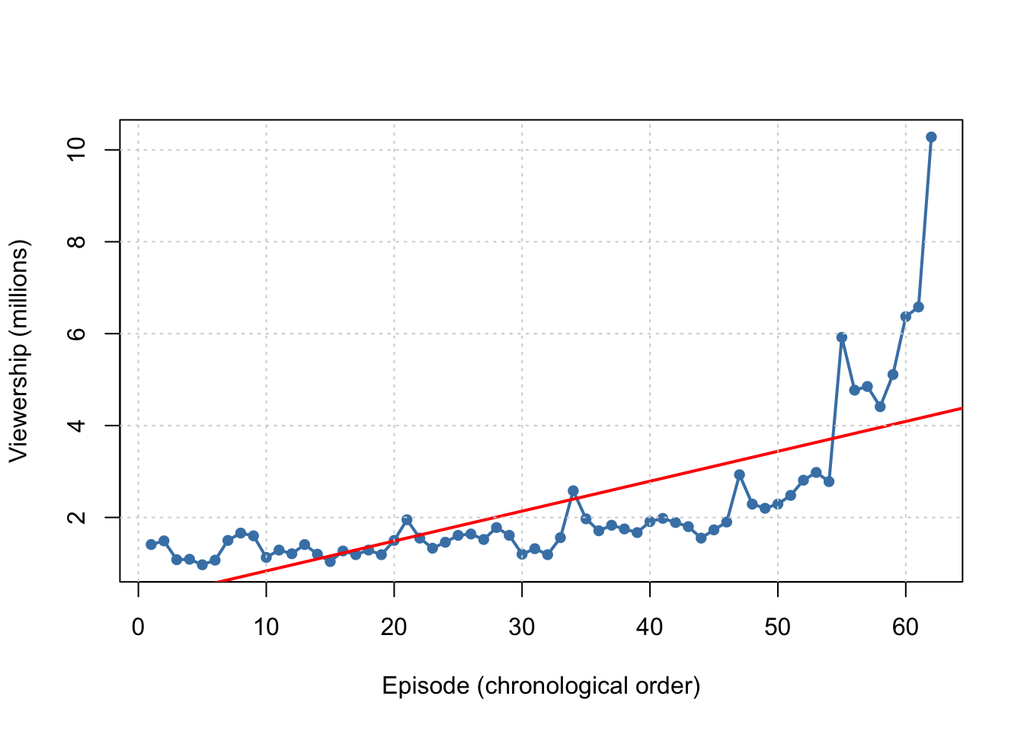

## Episode-to-episode viewers changes

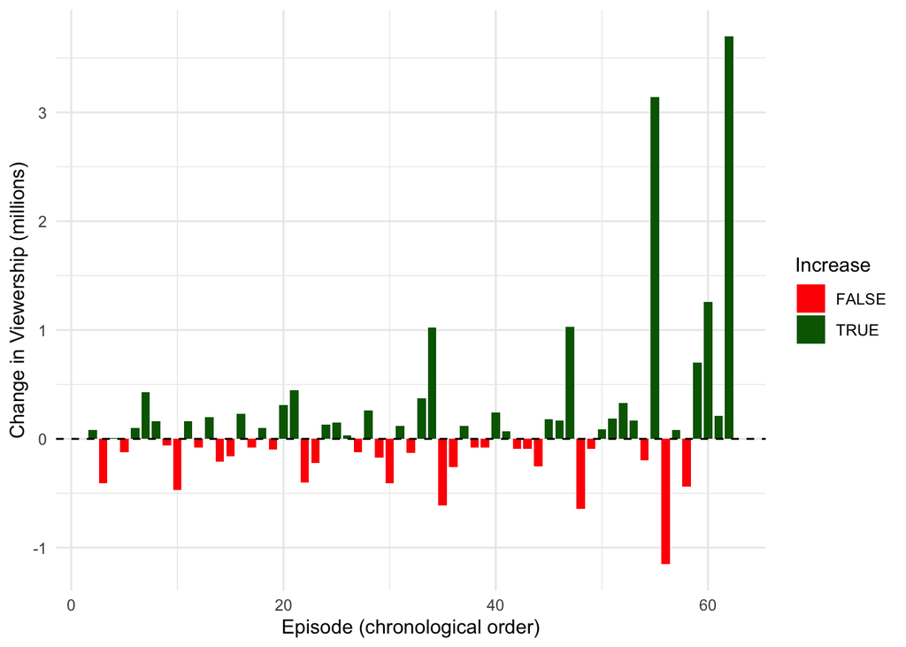

Breaking Bad Episode Ratings (IMDb)

| Episode_Number_Overall | Rating |
| --- | --- |
| 1 | 9.0 |
| 2 | 8.6 |
| 3 | 8.7 |
| 4 | 8.2 |
| 5 | 8.2 |
| 6 | 9.3 |
| 7 | 8.8 |
| 8 | 8.6 |
| 9 | 9.3 |
| 10 | 8.3 |
| 11 | 8.2 |
| 12 | 8.2 |
| 13 | 8.8 |
| 14 | 8.6 |
| 15 | 9.2 |
| 16 | 9.2 |
| 17 | 8.4 |
| 18 | 8.9 |
| 19 | 9.3 |
| 20 | 9.2 |
| 21 | 8.4 |
| 22 | 8.6 |
| 23 | 8.3 |
| 24 | 8.1 |
| 25 | 8.5 |
| 26 | 9.3 |
| 27 | 9.6 |
| 28 | 8.7 |
| 29 | 8.3 |
| 30 | 7.9 |
| 31 | 8.4 |
| 32 | 9.5 |
| 33 | 9.7 |
| 34 | 9.2 |
| 35 | 8.2 |
| 36 | 7.9 |
| 37 | 8.5 |
| 38 | 8.6 |
| 39 | 8.4 |
| 40 | 8.8 |
| 41 | 9.3 |
| 42 | 8.9 |
| 43 | 9.6 |
| 44 | 9.7 |
| 45 | 9.5 |
| 46 | 9.8 |
| 47 | 9.2 |
| 48 | 8.8 |
| 49 | 8.8 |
| 50 | 8.8 |
| 51 | 9.6 |
| 52 | 9.0 |
| 53 | 9.6 |
| 54 | 9.5 |
| 55 | 9.4 |
| 56 | 9.2 |
| 57 | 9.6 |
| 58 | 9.1 |
| 59 | 9.7 |
| 60 | 9.5 |
| 61 | 9.6 |